# Parcial 1 - Machine Learning

Norma Yuliana Cala, Lady Alexandra Duarte, Jhon Freddy Puentes

12/12/2020

# Etapa 1: Definición del problema

### ¿Qué se pretende predecir?

Se desea predecir la probabilidad de que un empleado se retire o no de la empresa.

### ¿De qué datos se dispone?

Disponemos de datos históricos de retiros de empleados en una empresa.

### ¿Cuál es la métrica de éxito?

Consideraremos como métrica de exito la creación del un modelo que sea capaz de p#predecir minimo el 90% de los casos de retiro.

# Etapa 2: Datos

el set de datos **`UNION_EMPLEADOS_RETIROS.csv`** contiene información sobre los empleados, datos de contratos y observaciones de retiros de empleados en una compañia. Además de esto, incluye las siguientes varibles adicionales:

- `FECHA`:
- `CODIGO_EMPRESA`: código unico de la compañia.
- `ID_GENERO`: Identificador del genero de la persona.
- `ID_ESTADO_CIVIL`: Identificador del estado civil.
- `FECHA_NACIMIENTO`: Fecha de nacimiento el empleado.
- `CODIGO_LOCALIDAD`: Identificador la localidad del empleado.
- `TIPO_NOMINA`: Tipo de vinculación de la persona con la empresa.
- `FECHA_INGRESO`: Fecha de inicio de labores en la compañia.
- `FECHA_INICIO_CONTRATO`: Fecha de inicio de labores en la compañia.
- `ID_CARGO`: Identificador del cargo del empleado.
- `TIPO_CARGO`: Descripción del tipo de cargo.
- `NIVEL_CARGO`: Identificador del nivel de cargo.
- `CATEGORIA_CARGO`: Identificador de la categoría del cargo.
- `TIPO_AREA`: Área de la compañia a la que pertenece o perteneció el empleado.
- `ID_CENTRO_COSTO`: Identificador del centro del costo.
- `SENAL_SINDICALIZADO`: Carácter que indica si es o era de un sindicato.
- `CLASE_EMPLEADO`: Descripción que indica la clase de empleado.
- `CLASE_NOMINA`: Identificador del tipo de vinculación de la persona con la empresa.
- `SUBSIDIO_TRANSPORTE`: Identificador que indica si tiene o tuvo subsidio de transporte.
- `PORCENTAJE_RIESGO`: Porcentaje de riesgo del cargo.
- `SALARIO`: Salario base del empleado.
- `COMPENSACION_VARIABLE`: Valor de compensación variable en caso de que reciba.
- `PORCENT_COMP_VARIABLE`: Valor en % de compensación variable en caso de que reciba.
- `TOTAL_SALARIO`: Total recibido por el empleado. salario + compensación variable.
- `CEDULA_ANONIMIZADA`: Identificador único del empleado en la base de datos.
- `UBICACION_ANONIMIZADA`: Identificador de la ubicación del empleado.
- `CAUSA_NOMBRE`: Descripción de la causa de retiro.
- `TIPO_DE_RETIRO`: Descripción del tipo de retiro del empleado.
- `FECHA_FIN_CONTRATO`: Fecha fin del contrato del empleado.

## Etapa Depuración Datos

*Para el conjunto de datos de Empleados y Retiros se realizó la siguiente depuración de registros con el consentimiento de que las descripciones siguientes no aportarían al modelo de predicción porque interfieren en las predicciones por ser datos que llevarían a una ppredicción direfente.* Total datos = 40.813únicos de toda la base = 1.872* Datos a Eliminar Edad menores de 18 años = 14 Nota: Registros con 2 y 11 años.* Causa nombre Eliminar Fallecidos = 151 Eliminar Pensionados = 411* Tipo Nomina Eliminar Aprendiz Sena = 2.072 Jubilados por la empresa = 297Por último se quitan todos los duplicados 36.289 y se dejamos el registro con el mayor salario para quedarnos con 1.579 registros únicos por cliente.

En la **`descripción del procesamiento y arreglo de la información`** se describen los procesos relizados a cada uno de los campos donde fue necesario realzar actividades como: homologaciones, cruces de datos entre vacios y los que contenían información para traer los datos correspondientes a cada uno de los registros necesarios para completar la información en las variables, asignación de registros DUMMY entre otros, a continuación se desglozan las actividades realizadas: Tipo texto = NO DEFINIDO Tipo número = 999999

- `Fecha` Se personaliza el formato de las fechas.

  | **FECHAS** | **FORMATO** |
  | --- | --- |
  | 2017-12-19 00:00:00 UTC | dd/MM/yyyy |

- `Género` Se encuentran 1.218 registros sin género, se procede a realizar el cruce de datos para encontrar el valor correspondiente para el registro.
- `Estado civil`: Las observaciones para el estado civil vienen de diferentes maneras por lo que se unifica la descripción y se homologan algunos registros. Para valores 0, vacios, ND, no definido se procede a realizar el cruce de datos para encontrar el valor correspondiente para el registro. Los que aún no se encontraron con valor se homologan con NO DEFINIDO. Algunas cédulas tenían asignados los valores de M y F por tal motivo se asignó el valor con mayor número según el conteo.

  | **VALOR** | **ASIGNACIÓN** |
  | --- | --- |
  | cas | CASADO |
  | div | DIVORCIADO |
  | sep | SEPARADO |
  | sol | SOLTERO |
  | uni | UNION LIBRE |
  | viu | VIUDO |
  | vacios | NO DEFINIDO |

- `Código localidad` Para los 2.293 registros con valores 0 y vacíos se realiza la búsqueda de información cruzando los campos vacíos con los que sí tienen información para para traer el valor. Si no hay se dejan como 999999.
- `Fecha Nacimiento` Se saca una nueva variable llamada Edad, restando el año actual con la fecha de nacimiento.
- `Tipo de Nómina` Esta columan de informacióon viene mezclados tanto códigos como descripción del tipo de nomina que tiene. Se hace necesario realizar cruces y trer información para completar la información que está como codficada con números. Lo que no se encuentre en la base se le asigna el valor DUMMY.

  | **VALOR** | **ASIGNACIÓN** |
  | --- | --- |
  | EST UNIVERSITARIO EN PRACTICA | APRENDIZ SENA |
  | vacías | NO DEFINIDO |

- `Tipo Cargo` Valores O, N/A, Vacías se realiza la búsqueda de información cruzando los campos vacíos con los que sí tienen información para para traer el valor

  | **VALOR** | **ASIGNACIÓN** |
  | --- | --- |
  | OPERATIVA | OPERATIVO |
  | DIRECCIÓN | DIRECCION |
  | DIRECTOR | DIRECTIVO |

- `ID Cargo` Se homologan así:

  | **VALOR** | **ASIGNACIÓN** |
  | --- | --- |
  | 0 | 999999 |
  | vacíos | 999999 |

- `Causa Nombre` Algunos nombres se referencian a lo mismo por tal motivo se hacen homologaciones.

  | **VALOR** | **ASIGNACIÓN** |
  | --- | --- |
  | PENSIÒN DE VEJEZ | PENSION DE VEJEZ |
  | PENSION DE VEJEZ | PENSION |
  | RENUNCIA | VOLUNTARIA |
  | TERMINACIÓN UNILATERAL | TERMINACION UNILATERAL |

- `Fecha inicio de contraro` Algunas columnas se encuentran con registros vacios y en la columna de inicio de contrato si registra datos, dicho de esta manera se traen los datos de esta columna para rellenar la columna faltante.
- `Tipo de retiro` Algunos campos se les realiza la homologación.

  | **VALOR** | **ASIGNACIÓN** |
  | --- | --- |
  | DESEADA | DESEADO |
  | No Deseada | NO DESEADO |

- `Id Cargo` Valor 0 se asigna el DUMMY de valor 999999
- `Nivel Cargo`

  | **VALOR** | **ASIGNACIÓN** |
  | --- | --- |
  | 0 | Vacíos |
  | -1 | Vacíos |
  | Vacios | 999999 |

- `Categoría Cargo`

  | **VALOR** | **ASIGNACIÓN** |
  | --- | --- |
  | 0 | Vacíos |
  | -1 | Vacíos |
  | Vacios | 999999 |

- `Tipo Area` Columna de información en donde se realizaron más homologaciones para las observaciones de los registros incluidos.

  | **VALOR** | **ASIGNACIÓN** |
  | --- | --- |
  | - | Vacíos |
  | 0 | Vacíos |
  | N/A | Vacíos |
  | ADMINISTRAVIVO | ADMINISTRATIVO |
  | OPERATIVA | OPERATIVO |
  | PRODUCCIÓN | PRODUCCION |
  | ADMINISTRACION PLANTA | PLANTA ADMINISTRATIVO |
  | MARCAS | MARCAS DE CANAL |
  | N/A | Vacíos |
  | N/A | Vacíos |
  | ADMINISTRATIVA PLANTA | ADMINISTRATIVO PLANTA |
  | ADMINISTRACION PLANTA | ADMINISTRATIVO PLANTA |
  | Vacíos | NO DEFINIDO |

- `Clase Empleado`

  | **VALOR** | **ASIGNACIÓN** |
  | --- | --- |
  | 0,3,4,5 | Vacíos |
  | Vacios | 999999 |

- `Porcentaje Riesgo` Para los valores que no tienen datos se les asigna el valor DUMMY correspondiente al tipo de dato en este caso 999999.
- `Total Salario` Se calcula el total salario con el calculo se define sumando las columnas de Salario más Compensación variable.
- `Retiro` Para los valores que se encontraron como vaciós se realiza la validación de que no tienen fecha de retiro ni causa de retiro y se les asigna el valor 0.

### Lectura de datos

```r
datos <- read.csv(file = 'UNION_EMPLEADOS_RETIROS.csv', sep = ';')
```

### Análisis exploratorio

```r
library(skimr)
```

```r
#skim(datos) # Comentar para generar PDF
```

#### Veamos algunos ejemplos de los datos

```r
head(datos, 8)
```

```
##   CEDULA_ANONIMIZADA      FECHA CODIGO_EMPRESA ID_GENERO ID_ESTADO_CIVIL
## 1                 50 31/12/2017             21         F         SOLTERO
## 2                158 31/12/2017             21         F         SOLTERO
## 3                215 31/12/2017             21         M         SOLTERO
## 4                279 31/12/2017             21         F         SOLTERO
## 5                319 31/12/2017             21         F         SOLTERO
## 6                376 31/12/2017             21         F         SOLTERO
## 7                382 31/12/2017             21         M     UNION LIBRE
## 8                390 31/12/2017             21         F          CASADO
##   FECHA_NACIMIENTO EDAD CODIGO_LOCALIDAD TIPO_NOMINA FECHA_INGRESO
## 1       14/08/1998   22           999999 NO DEFINIDO     1/06/2017
## 2       21/08/1997   23           999999 NO DEFINIDO    16/06/2017
## 3       12/04/1999   21           999999 NO DEFINIDO    19/04/2017
## 4       15/07/1995   25           999999 NO DEFINIDO     4/07/2017
## 5       21/01/1994   26           999999 NO DEFINIDO    16/01/2017
```

[output cut: 48 more lines]

### Número de observaciones y valores ausentes

```r
# datos %>% map_dbl(.f = function(x){ sum(is.na(x)) })
```

# Etapa 3: Pre-procesamiento

Decidimos estudiar y aprender a usar la libreria mlr3, nos gustó muchisimo lo potente y sencilla que es. Asi que la aplicamos al proyecto una vez estudiada.

```r
# Imporamos la libreria base.
library(mlr3)
```

Para definir la tarea del clsificador, lo primero que haremos es convertir la variable objetivo de tipo numeric a factor. Ya que asi lo requiere la instancia de task.

```r
datos$GRUPO <- ifelse(datos$RETIRO==1, 'RETIRADO', 'ACTIVO')
```

Validemos que en efecto sea de tipo factor.

```r
datos$GRUPO <- as.factor(datos$GRUPO)
class(datos$GRUPO)
```

```
## [1] "factor"
```

```r
# Convertir las columnas de datos categoricos como factores.
datos$ID_GENERO <- as.factor(datos$ID_GENERO)
datos$ID_ESTADO_CIVIL <- as.factor(datos$ID_ESTADO_CIVIL)
datos$TIPO_NOMINA <- as.factor(datos$TIPO_NOMINA)
datos$TIPO_CARGO <- as.factor(datos$TIPO_CARGO)
datos$TIPO_AREA <- as.factor(datos$TIPO_AREA)
datos$SENAL_SINDICALIZADO <- as.factor(datos$SENAL_SINDICALIZADO)
datos$CLASE_EMPLEADO <- as.factor(datos$CLASE_EMPLEADO)
datos$SUBSIDIO_TRANSPORTE <- as.factor(datos$SUBSIDIO_TRANSPORTE)
datos$CAUSA.NOMBRE <- as.factor(datos$CAUSA.NOMBRE)
datos$TIPO.DE.RETIRO <- as.factor(datos$TIPO.DE.RETIRO)

datos$FECHA  <- as.factor(datos$FECHA)
datos$FECHA.FIN.CONTRATO <- as.factor(datos$FECHA.FIN.CONTRATO)
datos$FECHA_INGRESO <- as.factor(datos$FECHA_INGRESO)
datos$FECHA_INICIO_CONTRATO <- as.factor(datos$FECHA_INICIO_CONTRATO)
datos$FECHA_NACIMIENTO <- as.factor(datos$FECHA_NACIMIENTO)
```

```r
# Convertir las columnnas con datos numericos a tipos numericos.
datos$COMPENSACION_VARIABLE <- as.numeric(datos$COMPENSACION_VARIABLE)
datos$PORCENTAJE_RIESGO  <- as.numeric(datos$PORCENTAJE_RIESGO)
datos$TOTAL_SALARIO <- as.numeric(datos$TOTAL_SALARIO)
```

## Elección de variables

Justificación desde el punto de vista de la elección de las variables predictoras. De forma manual creemos que las variables mas importantes seran:  
* edad * causa de retiro * fecha retiro * tipo de cargo * salario  
Ya que pueden influir en la desición de que una persona se vaya o no. Y las primeras variables porque estan directamente relacionadas con la variable objetivo. Es decir, si tiene causa de retiro es porque se retiró, de ahi viene la etiqueta.  
Sin embargo, usaremos la potencia de la libreria MLR3 para que indicarle al objeto learner y el task que hagan el feature selection automaticamente.

# Etapa 4: Modelado, pruebas, evaluación y optimizacion

```r
# Definimos una tarea para clasificar, configuramos los datos, la variable objetivo y la clase positiva.
task_clasificar <- TaskClassif$new(id = "datos", backend = datos, target = "GRUPO", positive = 'RETIRADO')
task_clasificar
```

```
## <TaskClassif:datos> (1579 x 32)
## * Target: GRUPO
## * Properties: twoclass
## * Features (31):
##   - fct (15): CAUSA.NOMBRE, CLASE_EMPLEADO, FECHA, FECHA.FIN.CONTRATO,
##     FECHA_INGRESO, FECHA_INICIO_CONTRATO, FECHA_NACIMIENTO,
##     ID_ESTADO_CIVIL, ID_GENERO, SENAL_SINDICALIZADO,
##     SUBSIDIO_TRANSPORTE, TIPO.DE.RETIRO, TIPO_AREA, TIPO_CARGO,
##     TIPO_NOMINA
##   - int (13): CATEGORIA_CARGO, CEDULA_ANONIMIZADA, CLASE_NOMINA,
##     CODIGO_EMPRESA, CODIGO_LOCALIDAD, EDAD, ID_CARGO, ID_CENTRO_COSTO,
##     NIVEL_CARGO, PORCENT_COMP_VARIABLE, RETIRO, SALARIO,
##     UBICACION_ANONIMIZADA
##   - dbl (3): COMPENSACION_VARIABLE, PORCENTAJE_RIESGO, TOTAL_SALARIO
```

Al imprimir el objeto `task_clasificar` podemos observar que nuestros target es la variable `GrUPO`, apreciamos que nuestro modelo posee 2 clases para clasificar: `RETIRADO` o `ACTIVO`; Finalmente, observamos que tenemos 31 features.

```r
# Definimos un objeto learner y lo inicializamos con el metodo de aprendizaje de clasificacion
learner_clasificar <- lrn("classif.rpart", cp = .01)
learner_clasificar
```

```
## <LearnerClassifRpart:classif.rpart>
## * Model: -
## * Parameters: xval=0, cp=0.01
## * Packages: rpart
## * Predict Type: response
## * Feature types: logical, integer, numeric, factor, ordered
## * Properties: importance, missings, multiclass, selected_features,
##   twoclass, weights
```

```r
# Veamos las variables mas importantes para el modelo
library("mlr3filters")
filter = flt("importance", learner = learner_clasificar)
filter$calculate(task_clasificar)
head(as.data.table(filter), 3)
```

```
##           feature    score
## 1:   CAUSA.NOMBRE 572.9297
## 2:         RETIRO 572.9297
## 3: TIPO.DE.RETIRO 534.8360
```

```r
# Division de datos para entrenamiento y pruebas desde el objeto (task_clasificar)
train_set <- sample(task_clasificar$nrow, 0.8 * task_clasificar$nrow)
test_set <- setdiff(seq_len(task_clasificar$nrow), train_set)
```

```r
# Entrenamos el modelo con los datos de (train_set)
learner_clasificar$train(task_clasificar, row_ids = train_set)
```

```r
# Realizamos la prediccion con el objeto learner_clasificar con los datos de (test_set)
prediction <- learner_clasificar$predict(task_clasificar, row_ids = test_set)
```

```r
# Veamos los resultados del modelo y como le fué con la prediccion en el set de pruebas.
print(prediction)
```

```
## <PredictionClassif> for 316 observations:
##     row_id    truth response
##         13   ACTIVO   ACTIVO
##         15   ACTIVO   ACTIVO
##         24   ACTIVO   ACTIVO
## ---
##       1566 RETIRADO RETIRADO
##       1575 RETIRADO RETIRADO
##       1578 RETIRADO RETIRADO
```

```r
head(as.data.table(prediction))
```

```
##    row_id  truth response
## 1:     13 ACTIVO   ACTIVO
## 2:     15 ACTIVO   ACTIVO
## 3:     24 ACTIVO   ACTIVO
## 4:     45 ACTIVO   ACTIVO
## 5:     46 ACTIVO   ACTIVO
## 6:     51 ACTIVO   ACTIVO
```

```r
# Veamos la matriz de confusion
prediction$confusion
```

```
##           truth
## response   RETIRADO ACTIVO
##   RETIRADO       91      0
##   ACTIVO          0    225
```

```r
# Veamos algunos datos de la predicción
head(prediction$data)
```

[output not shown]

[output cut: 94 more lines]

```r
# Veamos la metrica de exactitud de la prediccion
measure <- msr("classif.acc")
prediction$score(measure)
```

```
## classif.acc
##           1
```

# Re-construyamos la instancia del modelo usando Validacion Cruzada

```r
resampling_cross_validation <- rsmp("cv", folds = 3L)
resampling <- resample(task_clasificar, learner_clasificar, resampling_cross_validation)
```

```
## INFO  [23:33:43.549] Applying learner 'classif.rpart' on task 'datos' (iter 3/3)
## INFO  [23:33:43.591] Applying learner 'classif.rpart' on task 'datos' (iter 1/3)
## INFO  [23:33:43.632] Applying learner 'classif.rpart' on task 'datos' (iter 2/3)
```

```r
resampling$score(measure)
```

```
##                 task task_id                   learner    learner_id
## 1: <TaskClassif[45]>   datos <LearnerClassifRpart[33]> classif.rpart
## 2: <TaskClassif[45]>   datos <LearnerClassifRpart[33]> classif.rpart
## 3: <TaskClassif[45]>   datos <LearnerClassifRpart[33]> classif.rpart
##            resampling resampling_id iteration              prediction
## 1: <ResamplingCV[19]>            cv         1 <PredictionClassif[19]>
## 2: <ResamplingCV[19]>            cv         2 <PredictionClassif[19]>
## 3: <ResamplingCV[19]>            cv         3 <PredictionClassif[19]>
##    classif.acc
## 1:           1
## 2:           1
## 3:           1
```

```r
# Veamos la metrica de accuracy
resampling$aggregate(measure)
```

```
## classif.acc
##           1
```

```r
# Veamos la matriz de confusion.
resampling$prediction()$confusion
```

```
##           truth
## response   RETIRADO ACTIVO
##   RETIRADO      376      0
##   ACTIVO          0   1203
```

```r
# Cambiemos el tipo de prediccion del modelo para ver las probabilidades.
learner_clasificar$predict_type = "prob"
```

```r
# re-entrenamos el modelo
learner_clasificar$train(task_clasificar, row_ids = train_set)
```

```r
# Veamos que tiene el objeto modelo por dentro
learner_clasificar$model
```

```
## n= 1263
##
## node), split, n, loss, yval, (yprob)
##       * denotes terminal node
##
## 1) root 1263 285 ACTIVO (0.2256532 0.7743468)
##   2) CAUSA.NOMBRE=DESPIDO CON JUSTA CAUSA,DESPIDO SIN JUSTA CAUSA,MUTUO ACUERDO,PERIODO DE PRUEBA,RENUNCIA VOLUNTARIA,RETIRO VOLUNTARIO,TERMINACION PERIODO DE PRUEBA,TERMINACION UNILATERAL,VENCIMIENTO DE CONTRATO 285   0 RETIRADO (1.0000000 0.0000000) *
##   3) CAUSA.NOMBRE=NO APLICA 978   0 ACTIVO (0.0000000 1.0000000) *
```

```r
# Hacemos de nuevo una prediccion con los datos de pruebas.
prediction = learner_clasificar$predict(task_clasificar, row_ids = test_set)
```

```r
# Veamos respuestas y probabilidades juntas.
head(as.data.table(prediction))
```

```
##    row_id  truth response prob.RETIRADO prob.ACTIVO
## 1:     13 ACTIVO   ACTIVO             0           1
## 2:     15 ACTIVO   ACTIVO             0           1
## 3:     24 ACTIVO   ACTIVO             0           1
## 4:     45 ACTIVO   ACTIVO             0           1
## 5:     46 ACTIVO   ACTIVO             0           1
## 6:     51 ACTIVO   ACTIVO             0           1
```

```r
head(prediction$response)
```

```
## [1] ACTIVO ACTIVO ACTIVO ACTIVO ACTIVO ACTIVO
## Levels: RETIRADO ACTIVO
```

```r
head(prediction$prob)
```

```
##      RETIRADO ACTIVO
## [1,]        0      1
## [2,]        0      1
## [3,]        0      1
## [4,]        0      1
## [5,]        0      1
## [6,]        0      1
```

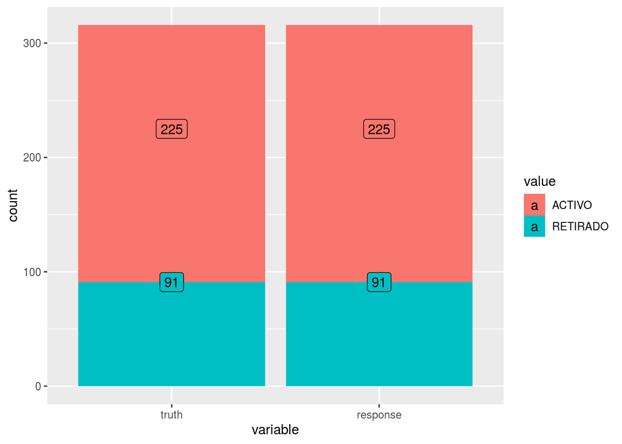

```r
library("mlr3viz")

autoplot(prediction)
```

# Curva ROC

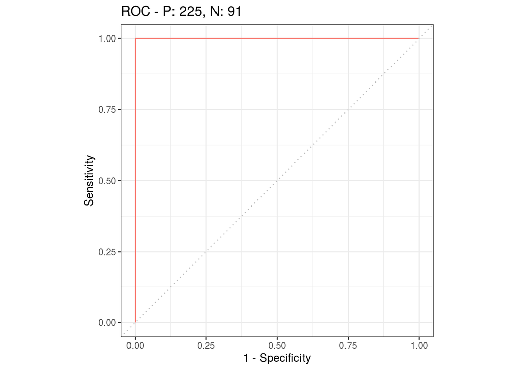

```r
ggplot2::autoplot(prediction, type = "roc")
```

# Precision vs Recall

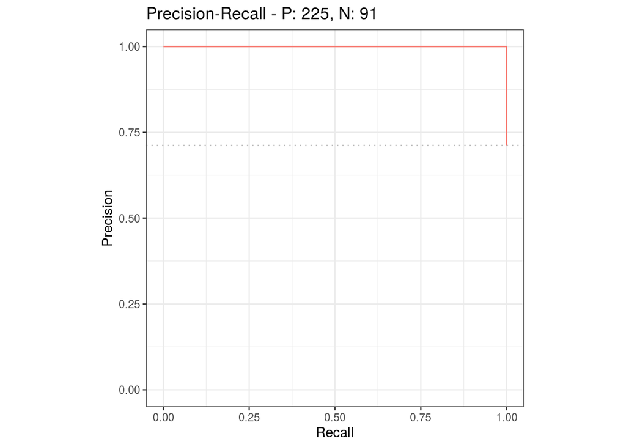

```r
ggplot2::autoplot(prediction, type = "prc")
```

```r
measure = msr("classif.acc")
prediction$score(measure)
```

```
## classif.acc
##           1
```

```r
measure_1 = msr("classif.bacc")
prediction$score(measure_1)
```

```
## classif.bacc
##            1
```

```r
measure_2 = msr("classif.ce")
prediction$score(measure_2)
```

```
## classif.ce
##          0
```

# Veamos ahora como manejamos el imbalance de clases con los metodos de undersample, oversample y smote

```r
# Veamos el tamaño de cada clase
table(task_clasificar$truth())
```

```
##
## RETIRADO   ACTIVO
##      376     1203
```

Se nota que estan bastante desbalanceadas las clases. Vamos a revisarlo.

### Vamos a disminuir la clase mayoritaria en 1/3

```r
# under = po("classbalancing", id = "undersample", adjust = "major", reference = "major", shuffle = FALSE, ratio = 1 / 3) # Comentar para generar PDF
# table(under$train(list(task_clasificar))$output$truth()) # Comentar para generar PDF
```

### Vamos a aumentar la clase minitoria a 3 veces.

```r
# over = po("classbalancing", id = "oversample", adjust = "minor", reference = "minor", shuffle = FALSE, ratio = 3) # Comentar para generar PDF
# table(over$train(list(task_clasificar))$output$truth()) # Comentar para generar PDF
```

Dado que no todas las variables son numericas, no podremos usar SMOTE por esta ocasion. Aunque podriamos pasar todo a numeros, pero no es un costo que asumiremos esta vez.

# Veamos las propiedades del modelo:

```r
learner_clasificar$model
```

```
## n= 1263
##
## node), split, n, loss, yval, (yprob)
##       * denotes terminal node
##
## 1) root 1263 285 ACTIVO (0.2256532 0.7743468)
##   2) CAUSA.NOMBRE=DESPIDO CON JUSTA CAUSA,DESPIDO SIN JUSTA CAUSA,MUTUO ACUERDO,PERIODO DE PRUEBA,RENUNCIA VOLUNTARIA,RETIRO VOLUNTARIO,TERMINACION PERIODO DE PRUEBA,TERMINACION UNILATERAL,VENCIMIENTO DE CONTRATO 285   0 RETIRADO (1.0000000 0.0000000) *
##   3) CAUSA.NOMBRE=NO APLICA 978   0 ACTIVO (0.0000000 1.0000000) *
```

# Etapa 5: Extracción de resultados para su uso en producción

```r
prediccion_todos_los_datos <- predict(learner_clasificar, datos, predict_type = "<Prediction>")


# Agregamos a los datos los valores de la prediccion
datos$prediccion <- prediccion_todos_los_datos$data$response
```

```r
# Seleccionamos solo las columnas de interes
library(dplyr)
resultado_final <- datos %>% select(CEDULA_ANONIMIZADA, GRUPO, prediccion )
head(resultado_final)
```

```
##   CEDULA_ANONIMIZADA  GRUPO prediccion
## 1                 50 ACTIVO     ACTIVO
## 2                158 ACTIVO     ACTIVO
## 3                215 ACTIVO     ACTIVO
## 4                279 ACTIVO     ACTIVO
## 5                319 ACTIVO     ACTIVO
## 6                376 ACTIVO     ACTIVO
```

```r
# install.packages("writexl")
library("writexl")
write_xlsx(resultado_final,"resultado_prediccion.xlsx")
```

# Etapa 6: Conclusiones y recomendaciones